# Sesion 23 - Datos Categoricos y Modelos de Grafos Probabilisticos Parte 6/7

Juan Carlos Martínez-Ovando

Maestría en Ciencia de Datos

Primavera 2019

# 1 Objetivos

En esta sesion:

- Estudiaremos definciones, propiedades y extensiones de los **modelos de grafos probabilisticos dirigidos** para datos categoricos.
- Estudiaremos definiciones y propiedades inferencias de los **modelos de grafos triangulados**.
- Implementaremos las soluciones con las librerias `gRbase` y `gRim`:

```
if(!requireNamespace("BiocManager", quietly = TRUE)){install.packages("BiocManager")}
BiocManager::install("graph", version = "3.8")
BiocManager::install("RBGL", version = "3.8")
BiocManager::install("Rgraphviz", version = "3.8")

install.packages("gRbase", dependencies=TRUE)
install.packages("gRim", dependencies=TRUE)
```

# 2 Modelo de grafo dirigido

> **Definicion:-** Un `grafo dirigido` es in grafo $\mathcal{G}=(V,E)$ en el que $E$ esta definido por `bordes dirigidos` (a.k.a. `fechas conectoras entre vertices`).

Los `grafos dirigidos` se denotan, por sus siglas en ingles, como `DG`.

> **Definicion:-** En adicion, un `DG` es `aciclico` si no tiene `ciclos` dirigidos (i.e. `trayectorias ciclicas` con flechas apuntando en la misma direccion hasta cerrar la `trayectoria` en un `vectice` dado).

Los `DG` `aciclicos` se denotan por `DAG`, por sus siglas en incles.

## 2.1 Ejemplo

Consideramos un ejemplo con `5` `nodos/vertices` y la siguiente conectividad:

```r
library("gRbase")
dag0 <- dag(~1, ~2*1, ~3*1*2, ~4*3*5, ~5*1)
dag0
```

```
## A graphNEL graph with directed edges
## Number of Nodes = 5
## Number of Edges = 6
```

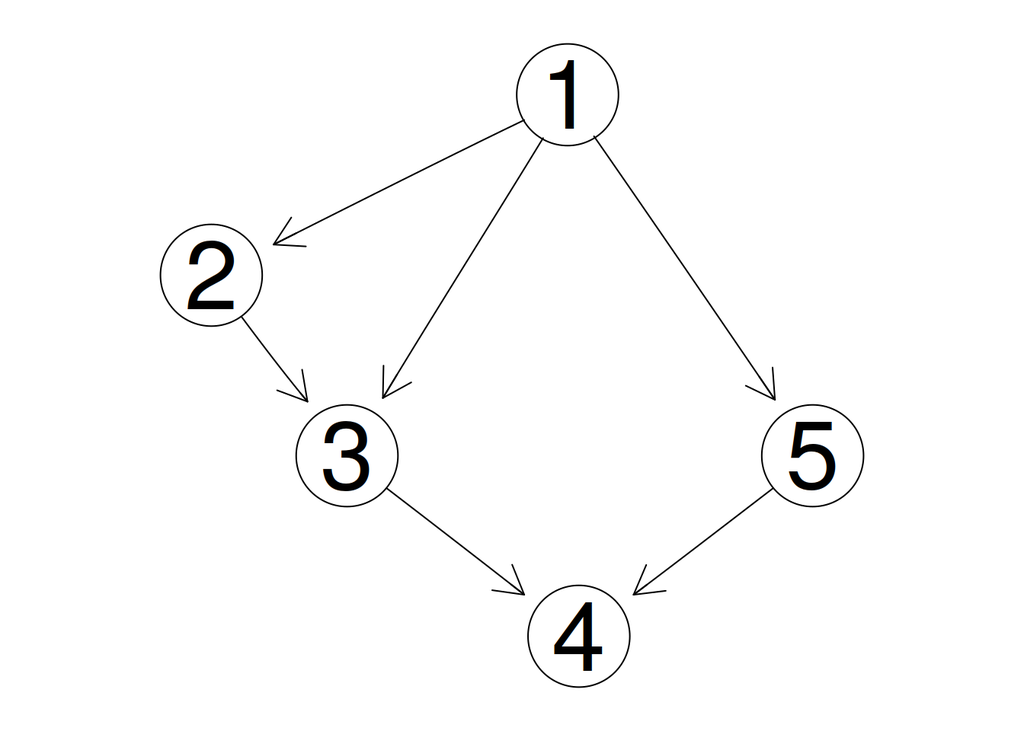

```r
plot(dag0)
```

Noten que al especificar los `bordes` en la funcion `dag()`, el orden de mencion no es simetrico.

Vemos un ejemplo donde cambiamos la direccion de dos nodos:
$$\{2,1\} \text{ y } \{5,1\},$$
por
$$\{1,2\} \text{ y } \{1,5\}.$$

```r
dag1 <- dag(~1, ~1*2,  ~3:1:2, ~4:3:5, ~1:5)
dag1
```

```
## A graphNEL graph with directed edges
## Number of Nodes = 5
## Number of Edges = 6
```

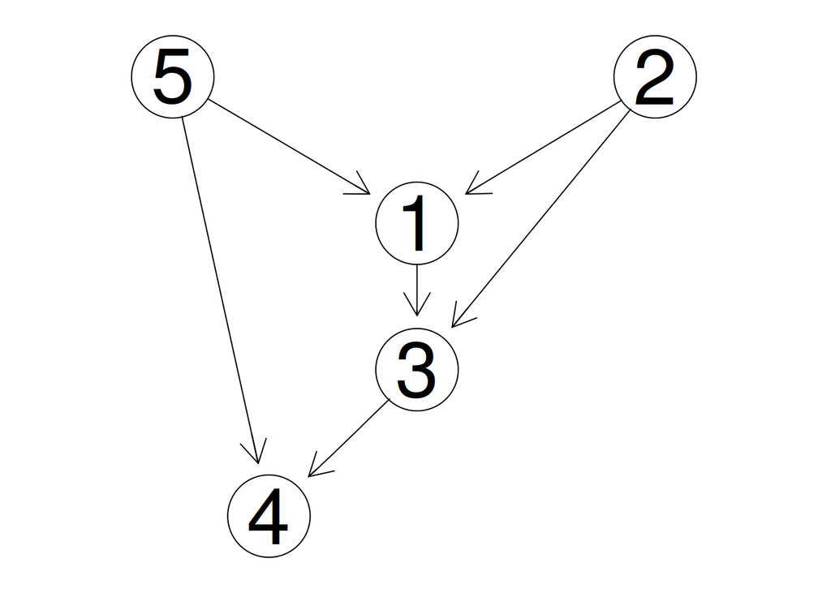

```r
plot(dag1)
```

> Revisen otras formas de expecificar los `bordes` en `dag()`.

La creacion de los `DAG`s puede hacerse a partir de la especificacion de `matrices de conectividad` (ala `matrices de adyacencia` no simetricas):

```r
m <- matrix(c(0, 0, 0, 0, 0,
              1, 0, 0, 0, 0,
              0, 1, 0, 0, 0,
              0, 1, 0, 0, 0,
              0, 0, 1, 1, 0),
            nrow = 5)
dagm <- as(m, "graphNEL")
dagm
```

```
## A graphNEL graph with directed edges
## Number of Nodes = 5
## Number of Edges = 5
```

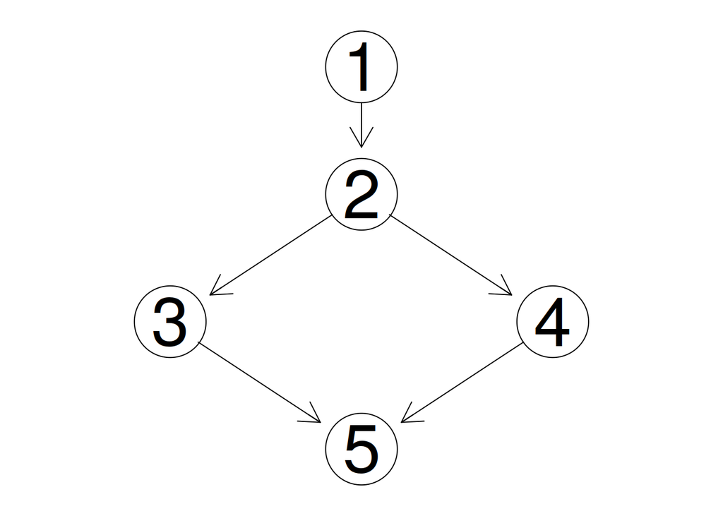

```r
plot(dagm)
```

## 2.2 Ascendentes y descendentes en DAG

La nocion de `parents` y `children` es relevante en los DAGs.

> **Definicion:-** Para un `vertice` $\beta\in V$, se define el conjunto `parents` de $\beta$, $Par_\beta$, como el conjunto de `nodos/vertices` $\alpha_i\in V$ tales que
> $$\alpha_i\rightarrow \beta.$$

> **Definicion:-** Para un `vertice` $\beta\in V$, se define el cnjunto `children` de $\beta$, $Chi_\beta$, como el conjunto de `nodos/vertices` $\gamma_i\in V$ tales que
> $$\beta \rightarrow \gamma_i.$$

Por ejemplo, respecto al DAG `dagm` anteriores:

```r
parents("4", dagm)
```

```
## [1] "2"
```

```r
children("4", dagm)
```

```
## [1] "5"
```

## 2.3 Factorizacion de DAG

Un `grafo probabilistico` con soporte discreto
$$X=(X_v)_{v\in V},$$
con $V$ asociada con un `DAG`
$$\mathcal{G}=(V,E),$$
y `masas de probabilidad` $p(x_v)$ puede factorizarse como
$$p(x_v)=\prod_{v\in V} p_{X_v|X_{Par_{v}}}(x_v|x_{Par_v}).$$

Retomemos el ejemplo del `dag0`:

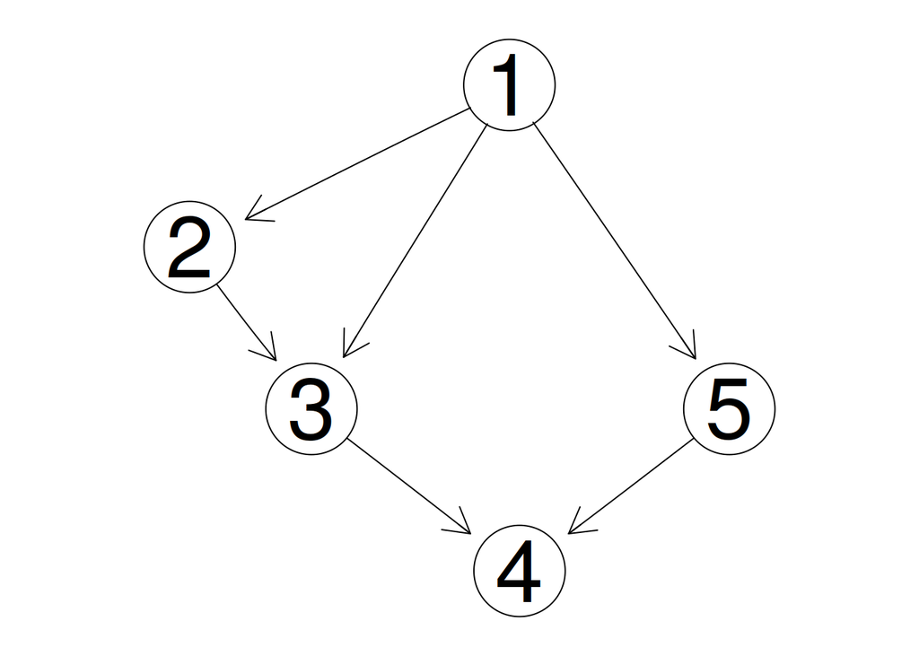

```r
plot(dag0)
```

En este caso, la factorizacion de $p(\cdot)$ para
$$X=(X_1,X_2,X_3,X_4,X_5),$$
se define como
$$p(x)=p_1(x_1)p(2|1)(x_2|x_1)p_{3|1,2}(x_3|x_1,x_2)p_{4|3,5}(x_4|x_3,x_5)p_{5|1}(x_5|x_1).$$

> El teorema de factorizacion de `DAG`s se refiere en alguna literatura como el `Teorema de Hammersley-Clifford`.

## 2.4 Comentarios

> Los `DAG`s estan relacionados con `factorizacion por independencia condicional`, pero no son estrictamente relacionados, porque `nociones de independencia condicional` puede seguir siendo `simetricas en probabilidad`, mientras que `DAG`s tal simetria no se cumple.

Consideremos los siguientes tres ejemplos:

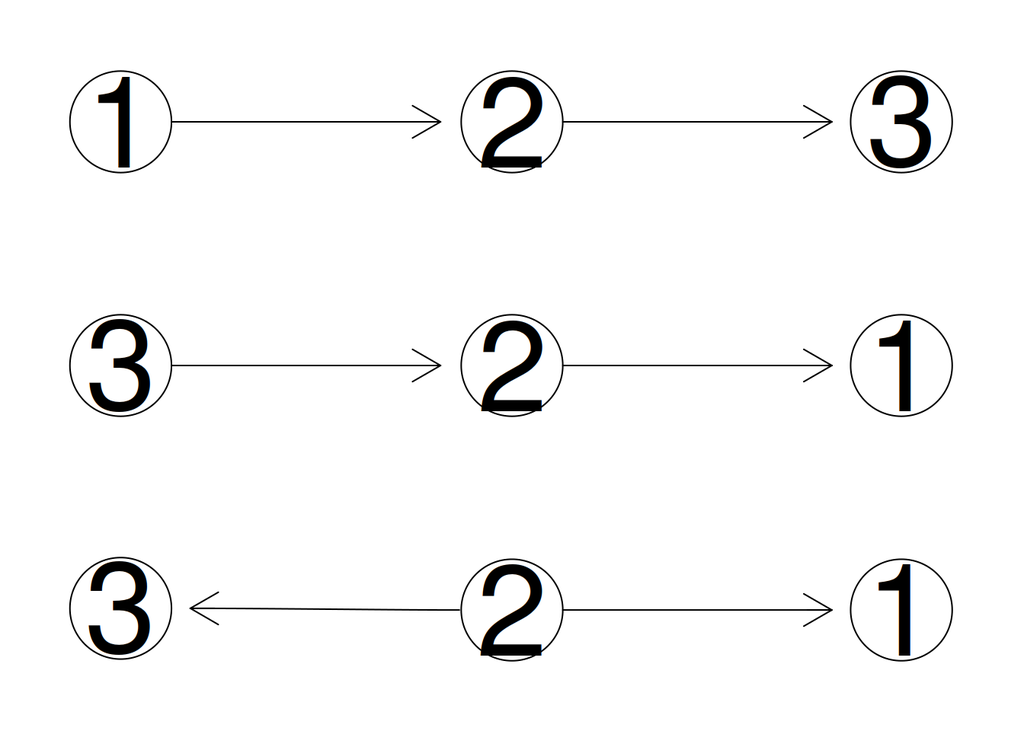

```r
par(mfrow=c(3,1),mar=c(3,1,2,1))
plot(dag(~1+2:1+3:2),"circo")
plot(dag(~3+2:3+1:2),"circo")
plot(dag(~2+1:2+3:2),"circo")
```

En estos ejemplos se sigue que
$$X_1 \mathrel{\text{$\perp\mkern-10mu\perp$}}X_3 | X_2.$$

> Revisen que se cumple la `propiedad de factorizacion` entre $\{X_1,X_2\}$ y $\{X_2,X_3\}$.

Sin embargo, en el siguiente caso `DAG`,

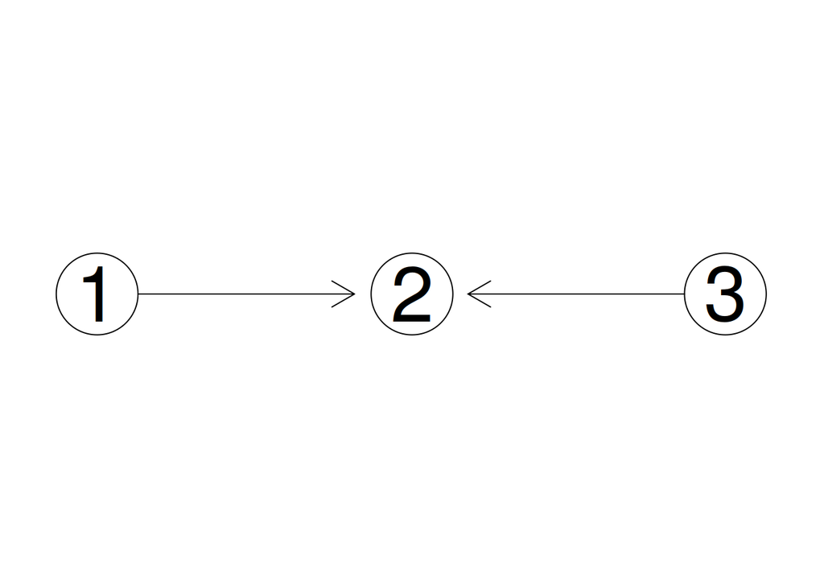

```r
plot(dag(~1+3+2:1:3),"circo")
```

Los pasos importantes en la defincion, estudio y uso de los `DAG` son:

1. Identificar los `bordes` entre los `parents` de cada `nodo`,
2. Reemplaza todos los `bordes dirigidos` por los `no dirigidos`, devolviendo así un `grafo no dirigido`.

Veamos este ejemplo:

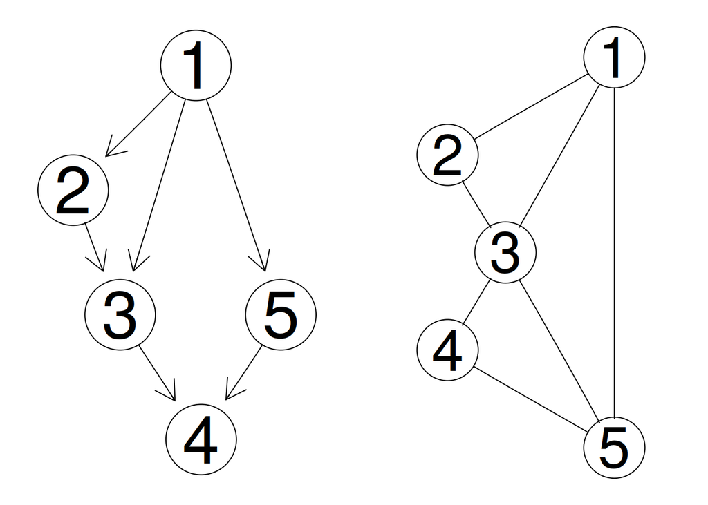

```r
dag0m <- moralize(dag0)
par(mfrow=c(1,2))
plot(dag0)
plot(dag0m)
```

> La factorizacion inducida por `DAG` es analoga a la que se obtiene por la `moralizacion` de `DAG`, como se muestra en el resultado anterior.

# 3 Redes bayesianas

> **Defincion:-** Una `red bayesiana` (`BN`, por sus siglas en ingles) es un `grafo probabilistico` basado en un `DAG`.

> Un `BN` satisface condiciones de `independencia condicional` en subgrafos contenidos en `BN`.

## 3.1 Ejemplo

Consideremos un ejemplo en el que se conectan tres dimensiones con base en las siguientes `premisas`:

> Tener gripe ($G$) puede causar una temperatura elevada ($F$). La temperatura elevada puede causar un dolor de cabeza ($D$).

La representacion del `grafo` asociado con estas `premisas` es

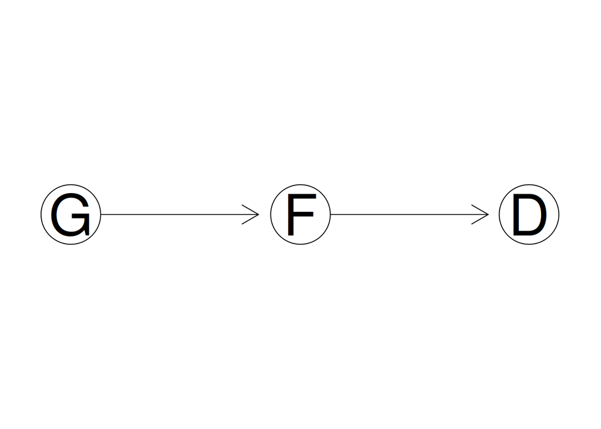

```r
gp.GFD <-dag(~ G + F:G + D:F)
plot(gp.GFD, "circo")
```

Definmos el conjunto de `vertices` como
$$V=\{G,F,D\},$$
con el `vector aleatorio`,
$$X=(X_v)_{v\in V}=(X_G,X_F,X_D),$$
donde
$$\mathcal{X}_v = \{1,2\},$$
con
$$X_v=\begin{cases}1, &\text{ no }v,\\2, &\text{ s }v,\end{cases}$$
para $v\in V$.

La regla de probabilidad asociada con $E$ es
$$\begin{eqnarray}
p(x) & = & p(x_G) p(x_F|x_G) p(x_D|x_F) \\
& = & p(G)p(F|G)p(D|F).
\end{eqnarray}$$

### 3.1.1 Casos

- Es facil verificar que $D$ (dolor de cabeza) es condicionalmente independiente de $G$ (gripe), condicional en $F$ (fiebre), i.e.
  $$(X_G \mathrel{\text{$\perp\mkern-10mu\perp$}}X_D) | X_F,$$
  o, analogamente,
  $$(G \mathrel{\text{$\perp\mkern-10mu\perp$}}D) | F.$$

### 3.1.2 Aprendizaje

Dado que hemos encontrado que un paciente tiene $D$ (dolor de cabeza), i.e.
$$X_{D,1}=2,$$
podemos calcular/actualizar las probabilidades condicionales para $X_{G,1}$ y $X_{F,1}$ dado $X_{D,1}=2$.

### 3.1.3 Componentes inciales

Antes de observar `evidencia`, necesitamos definir `probabilidades iniciales` con base en la descomposicion que vimos anteriormente:

```r
p.G <- parray("G", levels=2, values=c(.99,.01))
(p.G)
```

```
## G
##   G1   G2
## 0.99 0.01
## attr(,"class")
## [1] "parray" "array"
```

```r
p.FgG <- parray(c("F","G"), levels=c(2,2), values=c(.05,.95, .999,.001))
(p.FgG)
```

```
##     G
## F      G1    G2
##   F1 0.05 0.999
##   F2 0.95 0.001
## attr(,"class")
## [1] "parray" "array"
```

```r
p.DgF <- parray(c("D","F"), levels=c(2,2), values=c(.20,.80, .99,.01))
(p.DgF)
```

```
##     F
## D     F1   F2
##   D1 0.2 0.99
##   D2 0.8 0.01
## attr(,"class")
## [1] "parray" "array"
```

La representacion de la `tabla de contendencia` $G\times F\times D$, en terminos de las `probabilidades iniciales` asociadas con el `grafo de probabilidad`, son

```r
p.GF <- tableMult(p.G, p.FgG)
p.DFD <- tableMult(p.GF, p.DgF)
p.DFD
```

```
## , , G = G1
##
##     F
## D        F1       F2
##   D1 0.0099 0.931095
##   D2 0.0396 0.009405
##
## , , G = G2
##
##     F
## D          F1      F2
##   D1 0.001998 9.9e-06
##   D2 0.007992 1.0e-07
```

Estas `probabilidades conjuntas`, pueden escribirse como un `data.frame`

```r
p.DFD.df <- as.data.frame.table(p.DFD)
colnames(p.DFD.df) <- c("G","F","D","p_v")
p.DFD.df
```

```
##    G  F  D       p_v
## 1 D1 F1 G1 0.0099000
## 2 D2 F1 G1 0.0396000
## 3 D1 F2 G1 0.9310950
## 4 D2 F2 G1 0.0094050
## 5 D1 F1 G2 0.0019980
## 6 D2 F1 G2 0.0079920
## 7 D1 F2 G2 0.0000099
## 8 D2 F2 G2 0.0000001
```

## 3.2 Comentarios

> Las probabilidades actualizadas por la `observacion/configuracion` $X_{D,1}=2$, son generalmente dificiles de calcular directamente. Mas aun, cuando deseamos calcular la `actualizacion` con un conjunto `grande` de `datos/configuraciones` observadas.

> **Invitacion:-** Les invito a realizar la actualizacion anterior.

> **Comentario:-** Las actualizacion tendran `calculo facil` si representamos el modelo como un `grafo triangulado`.

## 3.3 Siguiente sesion

- Estudio/uso de `algoritmos bayesianos predictivos automaticos`.
- Estudio de `modelos de grafos causales`.